# Red Study

*N* removed NAs: 2

*N* removed typo: 1

*N* removed <18: 13

*N* total clean: 134

| Group | *N* | *M*<sub>age</sub> | *M*<sub>rating</sub> |
| --- | --- | --- | --- |
| Control | 67 | 20.9 | 6.82 |
| Experim | 67 | 21.2 | 5.81 |

**Main analysis results**

*t*(132) = 7.93, *p* < .001

[interactive chart not shown]

[figure not shown]

[interactive chart not shown]

# Red Study

Analysing Data, Lab Report

# Methods

## *Participants*

One hundred and thirty-four was the final number of participants whose data was included in the results. The mean age of participants was 21 years (range = 18-27) with a standard deviation of 1.92.

## *Design*

In this experiment, we examined how the colors red and white influence a woman´s perception of a man´s attractiveness. Sixty-seven participants were assigned the red condition, the experimental condition. White was selected for the control condition for being the most neutral achromatic color. Sixty-seven participants were assigned the white condition.

Age is a numeric type of variable. The variable condition is a factor (*0 = control, 1 = experimental*). Perceived attractiveness was evaluated with three items: “How attractive do you think this person is?” (ITEM_1), “How pleasant is this person to look at?” (ITEM_2) and “If I were to meet the person in this picture face to face, I would think he is attractive” (ITEM_3). As numeric variables, all three items are ratings with a range of 1 (*not at all attractive*) to 9 (*extremely attractive*) of possible scores.

Our hypothesis was that the either red or white condition (independent variable) affects the woman´s perceived attractiveness of a man (dependent variable), suggesting that participant´s ratings are influenced by color. To test this hypothesis, we will use a sample mean t-test.

# Results

Our composite score “Perceived Attractiveness” was calculated by taking the mean of the three items (ITEM_1, ITEM_2 and ITEM_3) in each domain / row for each participant.

The results of the means and SDs for each item for both conditions and the means and SDs for Perceived Attractiveness are the following:

| CONDITION | Mean (Item 1) | SD (Item 1) | Mean (Item 2) | SD (Item 2) | Mean (Item 3) | SD (Item 3) | Mean (Perceived Attractiveness) | SD (Perceived Attractiveness) |
| --- | --- | --- | --- | --- | --- | --- | --- | --- |
| 0 | 6.81 | 1.32 | 6.70 | 1.34 | 6.96 | 1.21 | 6.82 | 1.29 |
| 1 | 5.67 | 1.35 | 6.01 | 1.40 | 5.75 | 1.21 | 5.81 | 1.32 |

The results show that the means of each item in the white condition (*M(Item 1) = 6.81* and *SD (Item 1) = 1.32* , *M(Item 2) = 6.7* and SD(Item 2) = 1.34 , *M(Item 3) = 6,96* and *SD(Item 3) = 1.21*) were higher than in the red condition (*M(Item 1) = 5.67* and *SD(Item 1) = 1.35* , *M(Item 2) = 6.01* and *SD(Item 2) = 1.40* , *M(Item 3) = 5,75* and *SD(Item 3) = 1.21*).

As displayed in Figure 1, the mean rating of Perceived Attractiveness in the white condition (*M = 6.82 , SD = 1.29*) was also higher than the mean score of Perceived Attractiveness in the red condition (*M = 5.81 , SD = 1.32*).

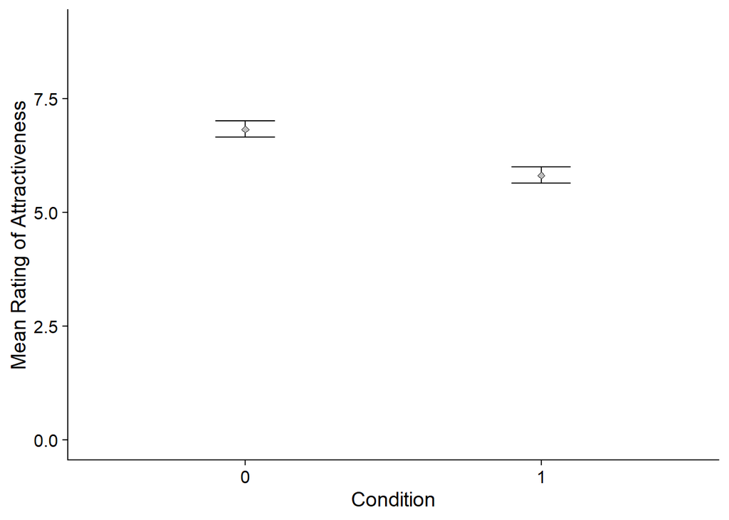

There is a significant difference of 1.01 rating points between the means of Perceived Attractiveness in the two conditions (*M<sup>white</sup>* - *M<sup>red</sup>* = 1.01). Based on our t-test, the value of t is very big (*t = 7.9326*); this means that the difference between our sample means of 1.01 was approx. 7.93 times greater than the standard error of the difference in means. Accordingly, there is a clear strong signal of noise compared to the amount of noise. However, that value is very unlikely to occur if in fact the true difference in means is 0 (*p-value* = 8.058e-13 , *p* < .001) what brings us to the conclusion that it is very unlikely that our sample means come from the same population. This shows that the null hypothesis may not be true and that there was a significant difference in the mean ratings of attractiveness of the red vs. white color conditions (*M<sup>diff</sup>* = 1.01, 95% Cl [0.76, 1.26], *t(132)* = 7.93, *p*<.001).

# Discussion

The results from this experiment supported our hypothesis that the colors red and white made a difference in the woman´s perceptions of a man´s attractiveness. However, participants in the white condition rated the man as more attractive, compared with those in the red condition. Our study show the opposite results from the original study, in which the results show that the color red increases woman´s perception of a man´s attractiveness (*Elliot, Andrew J., Greitenmeyer, Tobias, Gramzow, Richard H., Kayser, Daniela N., Lichtenfeld, Stephanie, Maier, Markus A. (2010) “Red, Rank, and Romance in Women Viewing Men”. Journal of Experimental Psychology: General. Vol. 139, No. 3, 399-417*). This means that there is still no sufficient evidence for the red effect.

There is a study that critizices the original study due to the presence of publication bias, which argues that the findings in the original study “are simply too good to be true” (*Francis, Gregory (2013) “Publication Bias in”Red, Rank, and Romance in Women Viewing Men" by Elliot et al. (2010)". Journal of Experimental Psychology: General. Vol. 142. No. 1, 292-296*). In the original study, the probability of the 12 tests rejecting the null hypothesis is 0.005, being extremely low. However, there is criticism that five cases that did not reject the null hypothesis and the 0.05 chance of making a Type I error of each of this five tests were not taken into consideration, leading to uncorrect results (Francis, 2013). Our very different results, compared to those of the original study, suggest that the findings in Elliot et al. do not provide valid evidence for the red effect, supporting the idea of possible publication bias in the original study.

Furthermore, another study (*Hesslinger, Vera M., Goldbach, Lisa, Carbon, Claus-Christian (2015) “Men in red: A reexamination of the red-attractiveness effect”. Psychon Bull Rev. 22:1142-1148*)reeximinated the red effect replicating the experiments of the original study while changing some aspects in the experiment, e.g tasting the whole sample in a group session instead of each participant individually, tasting German participants instead of American participants, etc. If the red effect presented in the original study wpuld be true, the results would be similar to those of this study (*Hesslinger et al. 2015*). However, the replications of the study do not show any significant red effect. The study even shows that other variables, such as apparel style, may affect woman´s perception of a man´s attractiveness, suggesting that the color red may not be the reason for an enhanced attraction and questioning the “general ecological validity” of the red effect: “it may well be the case that in a more naturalisting setting or in real life there are futher factors having greater impact” (*Hesslinger et al. 2015*)

There are some limitations in our study that should be taken into consideration. Because of the different conditions, we found that there is no evidence for the red-effect. However, this means that we are unable to see if the age of participants or futher individual factors did influence the results. Future studies may want to use a different model that includes a variety of many factors presented in real life scenarios, for instance, the age of participants, different styles, different photos of different men, etc. to avoid general invalidity.

All in all, taking the different results of replication studies and the possibility of publication bias into consideration, we conclude that the findings in the original study Elliot et al. do not provide enough valid evidence for the red-attractiveness effect and that the question if red enhances men´s attractiveness is still an open question, qhich requieres futher future research.

# References

*Elliot, Andrew J., Greitenmeyer, Tobias, Gramzow, Richard H., Kayser, Daniela N., Lichtenfeld, Stephanie, Maier, Markus A. (2010) “Red, Rank, and Romance in Women Viewing Men”. Journal of Experimental Psychology: General. Vol. 139, No. 3, 399-417*

*Francis, Gregory (2013) “Publication Bias in”Red, Rank, and Romance in Women Viewing Men" by Elliot et al. (2010)". Journal of Experimental Psychology: General. Vol. 142. No. 1, 292-296*

*Hesslinger, Vera M., Goldbach, Lisa, Carbon, Claus-Christian (2015) “Men in red: A reexamination of the red-attractiveness effect”. Psychon Bull Rev. 22:1142-1148*